# Wave Speed, Frequency, and Wavelength — Student Worksheet

**Unit: Waves — Lesson 03** Name: _______________________ Date: __________ Period: ____

## Phenomenon

Your teacher plucks a thick low string and a thin high string the same way — they sound like completely different notes. The wave speed on each string is fixed by the string itself, yet the pitches are not the same.

**Driving question:** If two notes travel at the same speed, what must be different about their waves?

## Notice & Wonder

| I notice… | I wonder… |
| --- | --- |

**Turn & Talk #1:** If two waves on a string travel at the same speed but have different frequencies, what has to be different about their wavelengths?

## Initial Model

Predict: if you keep the wave speed the same but **double the frequency**, what happens to the wavelength? Write your prediction and a reason.

> My reason: _______________________________________________

## Investigation

Open PhET *Wave on a String* in **oscillate** mode with the tension fixed (so the speed stays constant). Use the ruler to measure one wavelength at each frequency.

| Frequency f (Hz) | Wavelength λ (m) | Product f × λ |
| --- | --- | --- |

These figures show the pattern you are testing:

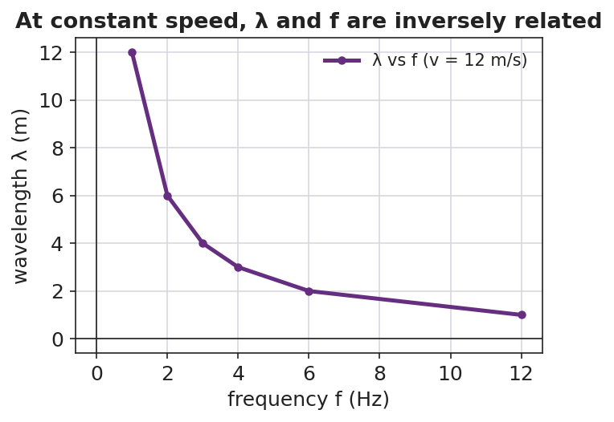

Wavelength versus frequency at constant speed — an inverse relationship.

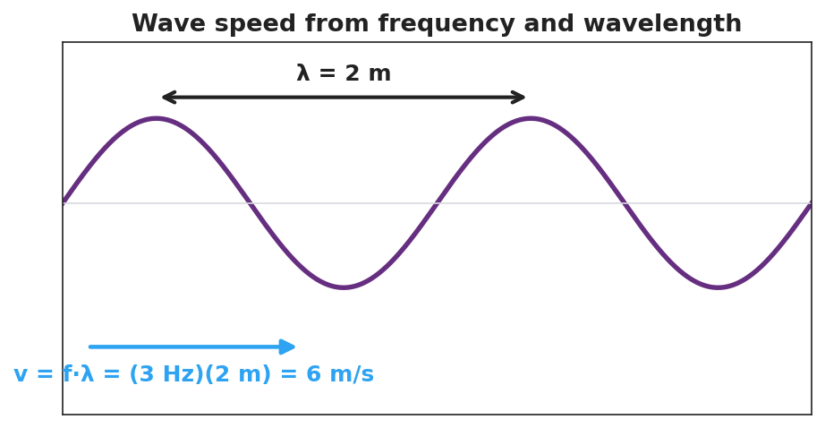

A wave labeled with λ = 2 m and the worked relationship v = f·λ = (3 Hz)(2 m) = 6 m/s.

**Key question:** What do you notice about the column f × λ? What does that product represent?

## Make It Make Sense

1. A wave travels at 340 m/s with a frequency of 170 Hz. Find its wavelength. Show v = f·λ rearranged.
2. At a fixed wave speed, you triple the frequency. What happens to the wavelength, and by what factor?
3. Write a Because/But/So sentence explaining why frequency and wavelength are inversely related at a constant wave speed.

## Vocabulary in Action

Use each term in a sentence about today’s investigation.

- **wave speed:** _______________________________________________
- **period:** _______________________________________________
- **hertz:** _______________________________________________

## Revise Your Model

Return to your prediction. Was it right? Rewrite it as a **Because / But / So** sentence using v = f·λ and the words *wave speed*, *frequency*, and *wavelength*.

> Because __________________________________________, but __________________________________________, so __________________________________________.

## Exit Ticket

A sound wave in air travels at 340 m/s.

1. A note has a frequency of 256 Hz. Find its wavelength. Show v = f·λ rearranged.
2. A higher note has a frequency of 512 Hz at the same speed. Without a calculator, is its wavelength longer or shorter, and by what factor?
3. What is the period of the 256 Hz note?